# MSDS458_Assignment_03_20210920_DEV_v20

### Review Distribution of Categorical Labels for the 114000 training data (news articles)

```python
from collections import Counter
train_categories = [categories[label] for label in train_dataset.map(lambda text, label: label).as_numpy_iterator()]
Counter(train_categories).most_common()
```

```
[('Business', 28531), ('Sports', 28495), ('World', 28491), ('Sci/Tech', 28483)]
```

Review Example with Interger Label(text, label pairs):

Review Example with Interger Label Encoded Classification(text, label pairs):

```python
for example, label in train_dataset.take(1):
  print('text: ', example.numpy())
  print('class: ', categories[label.numpy()])
```

```
text:  b'AMD #39;s new dual-core Opteron chip is designed mainly for corporate computing applications, including databases, Web services, and financial transactions.'
class:  Sci/Tech
```

#### Preprocessing Shuffle Data for Training and Create Batches of `(text, label)` pairs:

```python
BUFFER_SIZE = 10000
BATCH_SIZE = 64
```

```python
train_dataset = train_dataset.shuffle(BUFFER_SIZE).batch(BATCH_SIZE).prefetch(tf.data.experimental.AUTOTUNE)
validation_dataset = validation_dataset.shuffle(BUFFER_SIZE).batch(BATCH_SIZE).prefetch(tf.data.experimental.AUTOTUNE)
test_dataset = test_dataset.batch(BATCH_SIZE).prefetch(tf.data.experimental.AUTOTUNE)
```

```python
for example, label in train_dataset.take(2):
  print('texts: ', example.numpy()[:3])
  print()
  print('labels: ', label.numpy()[:3])
```

```
texts:  [b'ATLANTA -- Atlanta Braves shortstop Rafael Furcal has had his first court appearance after being arrested on charges of driving under the influence.'
 b'Reuters - A senior U.S. official said on Wednesday\\deals should not be done with hostage-takers ahead of the\\latest deadline set by Afghan Islamic militants who have\\threatened to kill three kidnapped U.N. workers.'
 b'SALT LAKE CITY -- The University of Utah football team still must wait another few weeks, but the time will be marked by anticipation rather than apprehension.']

labels:  [1 0 1]
texts:  [b'Nearly all its customers will be indemnified against claims that their use of Microsoft software infringed on any intellectual property claims.'
 b'The Bowl Championship Series is designed to match the No. 1 and No. 2 college football teams in an ultimate championship game. And when you examine the matchup for the Jan. 4 Orange Bowl - USC (12-0) and Oklahoma '
 b'Cingular Wireless, which yesterday finalized its purchase of AT amp;T Wireless, said the company will be governed from four regional centers -- one of them in Redmond -- by a combination of its executives and those from AT amp;T Wireless.']

labels:  [3 1 2]
```

```python
for example, label in train_dataset.take(2):
  print('texts: ', example.numpy()[:3])
  print()
  print('labels: ', [categories[n] for n in label.numpy()[:3]])
  print()
```

```
texts:  [b'ATLANTA A debate over evolution continues in Georgia almost 80 years after the Scopes Monkey Trial in Tennessee. Earlier this year, science teachers complained when schools superintendent Kathy Cox proposed '
 b'Early sighting of ID scheme budget-laundering'
 b'Controversy surrounding a current art exhibition (earlier reports here) being held in Berlin has deepened after an unusual stunt pulled on Wednesday by a German gymnast, said to be protesting over the dark legacy which is attached to the artworks on ']

labels:  ['Sci/Tech', 'Sci/Tech', 'World']

texts:  [b' TOKYO (Reuters) - Japan said China apologized on Tuesday  for the intrusion by one of its submarines into Japanese waters  last week in a gesture that defuses a dispute and may open the  way for a bilateral summit this weekend.'
 b'SYDNEY (Dow Jones)--Ronin Property Group (RPH.AU), the target of aA\\$1.3 billion takeover bid by Multiplex Group (MXGCA.AU), said Monday it has received an approach from a third party.'
 b'Yesterday #39;s 0-0 draw at Hearts left Rangers fourth behind Aberdeen and Kilmarnock and without an away goal in three league games.']

labels:  ['World', 'Business', 'Sports']
```

## Create the Text Encoder

The raw text loaded by `tfds` needs to be processed before it can be used in a model. The simplest way to process text for training is using the `experimental.preprocessing.TextVectorization` layer. This layer has many capabilities, but this tutorial sticks to the default behavior.

Create the layer, and pass the dataset's text to the layer's `.adapt` method: The processing of each sample contains the following steps:

```
standardize each sample (usually lowercasing + punctuation stripping)
split each sample into substrings (usually words)
recombine substrings into tokens (usually ngrams)
index tokens (associate a unique int value with each token)
transform each sample using this index, either into a vector of ints or a dense float vector.
```

The `.adapt` method sets the layer's vocabulary. Here are the first 20 tokens. After the padding and unknown tokens they're sorted by frequency:

```python
VOCAB_SIZE=1000
encoder = tf.keras.layers.experimental.preprocessing.TextVectorization(
    max_tokens=VOCAB_SIZE)
encoder.adapt(train_dataset.map(lambda text, label: text))
```

```python
vocab = np.array(encoder.get_vocabulary())
len(vocab)
```

```
1000
```

```python
vocab = np.array(encoder.get_vocabulary())
vocab[:20]
```

```
array(['', '[UNK]', 'the', 'a', 'to', 'of', 'in', 'and', 'on', 'for',
       'that', '39s', 'with', 'its', 'as', 'at', 'is', 'said', 'by', 'it'],
      dtype='<U14')
```

Here are the 20 least frequent words.

```python
vocab[-20:]
```

```
array(['black', 'turn', 'build', 'countrys', 'advanced', 'whose',
       'crisis', 'create', '23', 'sources', 'body', 'militant', 'hope',
       'event', 'started', 'ready', 'jones', 'lawsuit', 'focus',
       'singapore'], dtype='<U14')
```

```python
encoded_example = encoder(example)[:3].numpy()
encoded_example
```

```
array([[404,  28, 313,  17, 181,   1,   8,  44,   9,   2,   1,  18,  50,
          5,  13,   1,  62, 440,   1,  54,  76,   6,   3,   1,  10,   1,
          3,   1,   7, 107, 170,   2, 224,   9,   3,   1,   1,  40, 492,
          0,   0,   0,   0,   0,   0,   0,   0,   0,   0,   0,   0,   0,
          0,   0,   0,   0,   0,   0,   0,   0,   0,   0,   0,   0,   0,
          0],
       [  1,   1,   1,   1,  84,   1,   2, 966,   5,   1, 118, 676, 277,
         18,   1,  84,   1,  17,  42,  19,  20, 920,  22,   1,  23,   3,
        155, 494,   0,   0,   0,   0,   0,   0,   0,   0,   0,   0,   0,
          0,   0,   0,   0,   0,   0,   0,   0,   0,   0,   0,   0,   0,
          0,   0,   0,   0,   0,   0,   0,   0,   0,   0,   0,   0,   0,
          0],
       [ 52,  11,   1,   1,  15,   1, 230,   1, 413, 591,   1,   7,   1,
          7, 451,  22, 454, 877,   6,  79, 139, 203,   0,   0,   0,   0,
          0,   0,   0,   0,   0,   0,   0,   0,   0,   0,   0,   0,   0,
          0,   0,   0,   0,   0,   0,   0,   0,   0,   0,   0,   0,   0,
          0,   0,   0,   0,   0,   0,   0,   0,   0,   0,   0,   0,   0,
          0]])
```

```python
for n in range(3):
  print("Original: ", example[n].numpy())
  print("Round-trip: ", " ".join(vocab[encoded_example[n]]))
  print()
```

```
Original:  b' TOKYO (Reuters) - Japan said China apologized on Tuesday  for the intrusion by one of its submarines into Japanese waters  last week in a gesture that defuses a dispute and may open the  way for a bilateral summit this weekend.'
Round-trip:  tokyo reuters japan said china [UNK] on tuesday for the [UNK] by one of its [UNK] into japanese [UNK] last week in a [UNK] that [UNK] a [UNK] and may open the way for a [UNK] [UNK] this weekend

Original:  b'SYDNEY (Dow Jones)--Ronin Property Group (RPH.AU), the target of aA\\$1.3 billion takeover bid by Multiplex Group (MXGCA.AU), said Monday it has received an approach from a third party.'
Round-trip:  [UNK] [UNK] [UNK] [UNK] group [UNK] the target of [UNK] billion takeover bid by [UNK] group [UNK] said monday it has received an [UNK] from a third party

Original:  b'Yesterday #39;s 0-0 draw at Hearts left Rangers fourth behind Aberdeen and Kilmarnock and without an away goal in three league games.'
Round-trip:  yesterday 39s [UNK] [UNK] at [UNK] left [UNK] fourth behind [UNK] and [UNK] and without an away goal in three league games
```

## Create the model

[figure not shown]

Above is a diagram of the model.

1. This model can be build as a `tf.keras.Sequential`.
2. The first layer is the `encoder`, which converts the text to a sequence of token indices.
3. After the encoder is an embedding layer. An embedding layer stores one vector per word. When called, it converts the sequences of word indices to sequences of vectors. These vectors are trainable. After training (on enough data), words with similar meanings often have similar vectors.

   This index-lookup is much more efficient than the equivalent operation of passing a one-hot encoded vector through a `tf.keras.layers.Dense` layer.
4. A recurrent neural network (RNN) processes sequence input by iterating through the elements. RNNs pass the outputs from one timestep to their input on the next timestep.

**tf.keras.layers.Bidirectional**  
https://www.tensorflow.org/api_docs/python/tf/keras/layers/Bidirectional

[figure not shown]

```python
num_classes = 4
model = tf.keras.Sequential([
                              encoder
                              ,tf.keras.layers.Embedding(input_dim=len(encoder.get_vocabulary())
                              ,output_dim=64
                                # Use masking to handle the variable sequence lengths
                              ,mask_zero=True)
                              ,tf.keras.layers.Bidirectional(tf.keras.layers.LSTM(64))
                              ,tf.keras.layers.Dense(64, activation='relu')
                              ,tf.keras.layers.Dense(num_classes,activation='softmax')   # num_classes = 4
])
```

Please note that we choose to Keras sequential model here since all the layers in the model only have single input and produce single output.

**tf.keras.Model**  
https://www.tensorflow.org/api_docs/python/tf/keras/Model

## Compile Model

**tf.keras.losses.SparseCategoricalCrossentropy**  
https://www.tensorflow.org/api_docs/python/tf/keras/losses/SparseCategoricalCrossentropy

```python
model.compile(optimizer=tf.keras.optimizers.Adam(1e-4)
              ,loss=tf.keras.losses.SparseCategoricalCrossentropy() # if we set from_logits=True we don not have specify a softmax activation function in the last layer
              ,metrics=['accuracy'])
```

Please note that Keras sequential model is used here since all the layers in the model only have single input and produce single output. In case you want to use stateful RNN layer, you might want to build your model with Keras functional API or model subclassing so that you can retrieve and reuse the RNN layer states. Please check [Keras RNN guide](https://www.tensorflow.org/guide/keras/rnn#rnn_state_reuse) for more details.

The embedding layer uses masking to handle the varying sequence-lengths. All the layers after the `Embedding` support masking:

```python
print([layer.supports_masking for layer in model.layers])
```

```
[False, True, True, True, True]
```

## Train the model

**Module: tf.keras.callbacks**

**tf.keras.callbacks.EarlyStopping**  
https://www.tensorflow.org/api_docs/python/tf/keras/callbacks/EarlyStopping

**tf.keras.callbacks.ModelCheckpoint**  
https://www.tensorflow.org/api_docs/python/tf/keras/callbacks/ModelCheckpoint

```python
history = model.fit(train_dataset
                    ,epochs = 200
                    ,validation_data=validation_dataset
                    ,callbacks=[tf.keras.callbacks.EarlyStopping(monitor='val_accuracy', patience=2)]
                    )
```

```python
test_loss, test_acc = model.evaluate(test_dataset)

print('Test Loss: {}'.format(test_loss))
print('Test Accuracy: {}'.format(test_acc))
```

```
Test Loss: 0.41578543186187744
Test Accuracy: 0.8464473485946655
```

## Plotting Performance Metrics - Single Layer Bidirectional RNN

We use Matplotlib to create 2 plots--displaying the training and validation loss (resp. accuracy) for each (training) epoch side by side.

```python
history_dict = history.history
history_dict.keys()
```

```
dict_keys(['loss', 'accuracy', 'val_loss', 'val_accuracy'])
```

```python
history_df=pd.DataFrame(history_dict)
history_df.tail(10).round(3)
```

|  | loss | accuracy | val_loss | val_accuracy |
| --- | --- | --- | --- | --- |
| 0 | 0.718 | 0.729 | 0.483 | 0.834 |
| 1 | 0.463 | 0.834 | 0.446 | 0.849 |
| 2 | 0.433 | 0.844 | 0.422 | 0.854 |
| 3 | 0.412 | 0.851 | 0.407 | 0.860 |
| 4 | 0.399 | 0.855 | 0.411 | 0.854 |
| 5 | 0.390 | 0.859 | 0.395 | 0.857 |

```python
losses = history.history['loss']
accs = history.history['accuracy']
val_losses = history.history['val_loss']
val_accs = history.history['val_accuracy']
epochs = len(losses)
```

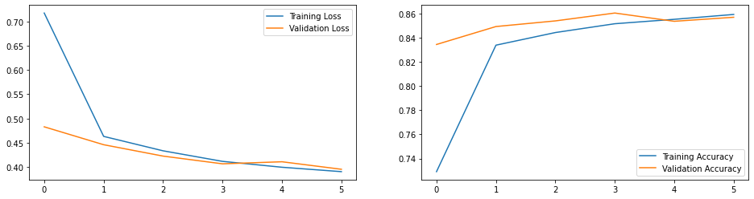

```python
plt.figure(figsize=(16, 4))
for i, metrics in enumerate(zip([losses, accs], [val_losses, val_accs], ['Loss', 'Accuracy'])):
    plt.subplot(1, 2, i + 1)
    plt.plot(range(epochs), metrics[0], label='Training {}'.format(metrics[2]))
    plt.plot(range(epochs), metrics[1], label='Validation {}'.format(metrics[2]))
    plt.legend()
plt.show()
```

## Model Architecture Summary Single Layer Bidirectional RNN

```python
model.summary()
```

```
Model: "sequential"
_________________________________________________________________
Layer (type)                 Output Shape              Param #
=================================================================
text_vectorization_2 (TextVe (None, None)              0
_________________________________________________________________
embedding (Embedding)        (None, None, 64)          64000
_________________________________________________________________
bidirectional (Bidirectional (None, 128)               66048
_________________________________________________________________
dense (Dense)                (None, 64)                8256
_________________________________________________________________
dense_1 (Dense)              (None, 4)                 260
=================================================================
Total params: 138,564
Trainable params: 138,564
Non-trainable params: 0
_________________________________________________________________
```

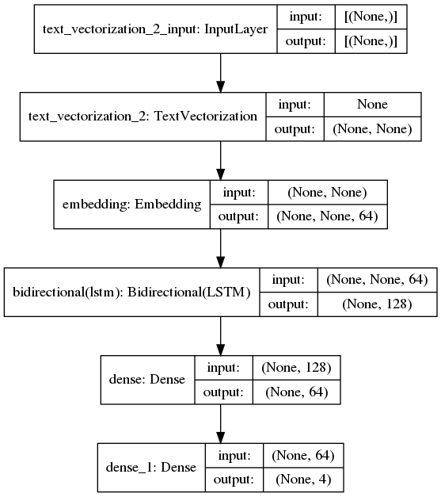

```python
keras.utils.plot_model(model, "BiDirectionalLSTM.png", show_shapes=True)
```

## Stack two or more LSTM layers

Keras recurrent layers have two available modes that are controlled by the `return_sequences` constructor argument:

- If `False` it returns only the last output for each input sequence (a 2D tensor of shape (batch_size, output_features)). This is the default, used in the previous model.
- If `True` the full sequences of successive outputs for each timestep is returned (a 3D tensor of shape `(batch_size, timesteps, output_features)`).

The interesting thing about using an `RNN` with `return_sequences=True` is that the output still has 3-axes, like the input, so it can be passed to another RNN layer, like this:

[figure not shown]

```python
model2 = tf.keras.Sequential([
                              encoder
                              ,tf.keras.layers.Embedding(len(encoder.get_vocabulary()), 64, mask_zero=True)
                              ,tf.keras.layers.Bidirectional(tf.keras.layers.LSTM(64,  return_sequences=True))
                              ,tf.keras.layers.Bidirectional(tf.keras.layers.LSTM(32))
                              ,tf.keras.layers.Dense(64, activation='relu')
                              ,tf.keras.layers.Dropout(0.5)
                              ,tf.keras.layers.Dense(num_classes,activation='softmax')   # not binary since there are num_classes categories
])
```

**tf.keras.losses.SparseCategoricalCrossentropy**  
https://www.tensorflow.org/api_docs/python/tf/keras/losses/SparseCategoricalCrossentropy

```python
model2.compile(optimizer='adam'
              ,loss=tf.keras.losses.SparseCategoricalCrossentropy() # if we set from_logits=True we do not have specify a softmax activation function in the last layer
              ,metrics=['accuracy'])
```

```python
history2 = model2.fit(train_dataset
                    ,epochs=200
                    ,validation_data=validation_dataset
                    ,validation_steps=30
                    ,callbacks=[tf.keras.callbacks.EarlyStopping(monitor='val_accuracy', patience=2)]
                    )
```

```python
test_loss, test_acc = model2.evaluate(test_dataset)

print('Test Loss: {}'.format(test_loss))
print('Test Accuracy: {}'.format(test_acc))
```

```
Test Loss: 0.4058394730091095
Test Accuracy: 0.8532894849777222
```

## Plotting Performance Metrics - Multi-Layer Bidirectional RNN

We use Matplotlib to create 2 plots--displaying the training and validation loss (resp. accuracy) for each (training) epoch side by side.

```python
history_dict2 = history2.history
history_dict2.keys()
```

```
dict_keys(['loss', 'accuracy', 'val_loss', 'val_accuracy'])
```

```python
history2_df=pd.DataFrame(history_dict2)
history2_df.tail().round(3)
```

|  | loss | accuracy | val_loss | val_accuracy |
| --- | --- | --- | --- | --- |
| 0 | 0.510 | 0.817 | 0.421 | 0.855 |
| 1 | 0.424 | 0.852 | 0.421 | 0.848 |
| 2 | 0.402 | 0.858 | 0.388 | 0.855 |

```python
losses = history2.history['loss']
accs = history2.history['accuracy']
val_losses = history2.history['val_loss']
val_accs = history2.history['val_accuracy']
epochs = len(losses)
```

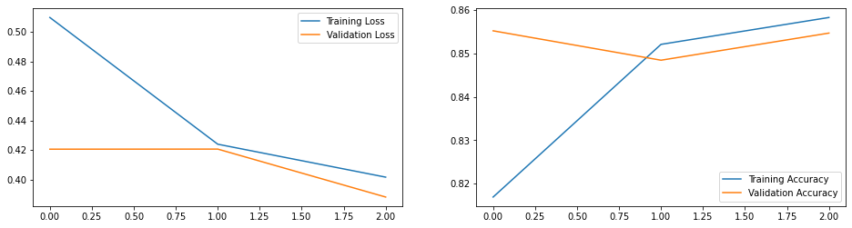

```python
plt.figure(figsize=(16, 4))
for i, metrics in enumerate(zip([losses, accs], [val_losses, val_accs], ['Loss', 'Accuracy'])):
    plt.subplot(1, 2, i + 1)
    plt.plot(range(epochs), metrics[0], label='Training {}'.format(metrics[2]))
    plt.plot(range(epochs), metrics[1], label='Validation {}'.format(metrics[2]))
    plt.legend()
plt.show()
```

```python
preds = model.predict(test_dataset)
```

```python
preds.shape
```

```
(7600, 4)
```

```python
cm = sns.light_palette((260, 75, 60), input="husl", as_cmap=True)
```

```python
df = pd.DataFrame(preds[0:15]
                  ,columns = ['World','Sports','Business','Sci/Tech']).T
df.style.format("{:.2%}").background_gradient(cmap=cm)
```

|  | 0 | 1 | 2 | 3 | 4 | 5 | 6 | 7 | 8 | 9 | 10 | 11 | 12 | 13 | 14 |
| --- | --- | --- | --- | --- | --- | --- | --- | --- | --- | --- | --- | --- | --- | --- | --- |
| World | 0.85% | 99.85% | 0.09% | 1.43% | 99.74% | 0.60% | 0.73% | 26.15% | 93.99% | 2.81% | 99.93% | 0.23% | 0.75% | 95.31% | 99.78% |
| Sports | 98.90% | 0.00% | 0.00% | 98.28% | 0.02% | 0.10% | 98.96% | 68.45% | 0.74% | 0.01% | 0.00% | 0.22% | 0.00% | 0.50% | 0.00% |
| Business | 0.06% | 0.13% | 1.81% | 0.03% | 0.08% | 17.13% | 0.04% | 0.31% | 1.10% | 83.47% | 0.07% | 0.30% | 97.61% | 1.47% | 0.17% |
| Sci/Tech | 0.20% | 0.02% | 98.10% | 0.25% | 0.16% | 82.18% | 0.27% | 5.10% | 4.17% | 13.71% | 0.00% | 99.25% | 1.64% | 2.72% | 0.05% |

```python
model2.summary()
```

```
Model: "sequential_1"
_________________________________________________________________
Layer (type)                 Output Shape              Param #
=================================================================
text_vectorization_2 (TextVe (None, None)              0
_________________________________________________________________
embedding_1 (Embedding)      (None, None, 64)          64000
_________________________________________________________________
bidirectional_1 (Bidirection (None, None, 128)         66048
_________________________________________________________________
bidirectional_2 (Bidirection (None, 64)                41216
_________________________________________________________________
dense_2 (Dense)              (None, 64)                4160
_________________________________________________________________
dropout (Dropout)            (None, 64)                0
_________________________________________________________________
dense_3 (Dense)              (None, 4)                 260
=================================================================
Total params: 175,684
Trainable params: 175,684
Non-trainable params: 0
_________________________________________________________________
```

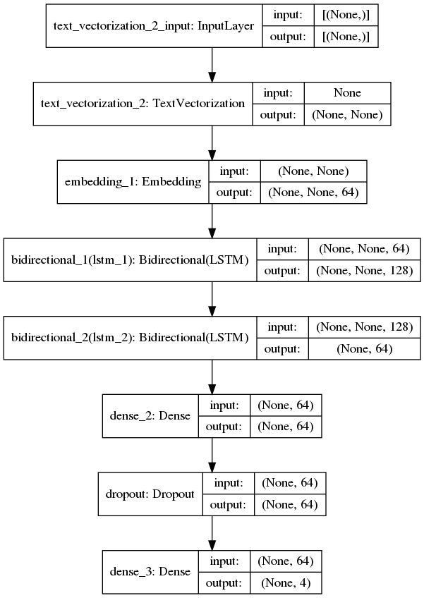

```python
keras.utils.plot_model(model2, "2Layer_BiDirectionalLSTM.png", show_shapes=True)
```

Check out other existing recurrent layers such as [GRU layers](https://www.tensorflow.org/api_docs/python/tf/keras/layers/GRU).

If you're interestied in building custom RNNs, see the Keras RNN Guide.